# Final_Project

201221420 강정호

```r
#라이브러리 함수 모음
#install.packages("dplyr")
#install.packages("magrittr")
#install.packages("reshape2")
#install_github("plgrmr/readAny", force = TRUE)
#install.packages("Rcpp")
library("xlsx")
library(dplyr)
library(magrittr)
```

```r
library(xlsx)
library(ggplot2)
library(MASS)
library(devtools)
library(reshape2)
library(lattice)
library(wordcloud2)
library(readAny)
```

# 주제선정 : 영화 흥행에 미치는 요인 상관관계

다른 산업에 비해 고위험, 고수익인 영화 산업은 콘텐츠 제작 후 단시간에 성공 유무가 판가름 나는 편이다. 개봉 전까지 몇 달동안 막대한 마케팅 비용을 쓰고도 개봉 1~2주 만에 실패가 결정되기도 하는 것이다. 그렇다 보니 영화 흥행의 답을 알아내고자 하는 산업 관계자들이 많았다. 그러나 여전히 이에 대한 답은 아무도 모른다. 개봉 스크린수, 배우 및 감독의 영향력, 배급사의 영향력, 제작 국가, 평점, 댓글 등 영화 흥행에 영향을 미치는 요소는 다양하다. 그리고 개봉 시기의 정치, 언론, 사회 환경도 영향을 미친다. 이러한 영화 흥행 요소에 대한 연구는 1970년대부터 진행되어 왔다. 선행연구들을 토대로 영화는 크게 제작자 측면에 해당되는 내재적 변수와 소비자 요인에서 접근하는 정보 원천 변수에 가장 영향을 받는다. 제작자 측면은 감독, 유명 배우, 스크린 수, 개봉 시즌, 관람등급, 배급사 및 장르 등이며, 소비자 측면은 단순한 평점부터 온라인 구전 점수, 구전 크기 등이다. 이처럼 영화 흥행에 영향을 줄 수 있는 요소는 무척 다양하며, 각 요소의 영향력도 일관적이지 않아 다양한 요소들이 동시에 복합적으로 영향을 끼친다고 결론을 내리고 있다.

# 과제 목표

영화의 흥행에 미치는 요인으로 예산, 댓글 수, 평점, 스크린 수, 배급사를 요인으로 정하여 영화의 수익과 비교하여 흥행을 분석한다. 영화 흥행을 분석하기 위한 데이터로는 국내 IPTV, 국내 Box Office 통계, 해외 Box office 통계이다.

# 1. 2018년 국내 박스오피스

## 국내에서 개봉한 2150개의 영화의 매출액, 매출액점유율, 관객수, 스크린수, 상영횟수 분석

- 데이터 컬럼 설명
- 순위 : 매출액을 기준으로 내림차순 정렬
- 영화명
- 매출액 : 영화로 벌어들이 총 매출
- 매출액 점유율 : 모든 영화의 매출액에서 차지하는 비율
- 관객 수
- 스크린 수 : 극장에서 영화가 점유하는 스크린 수
- 상영 횟수
- 대표 국적 : 영화를 제작한 주요 국가
- 국적 : 영화를 보조 제작한 국가
- 배급사 : 영화를 유통한 회사

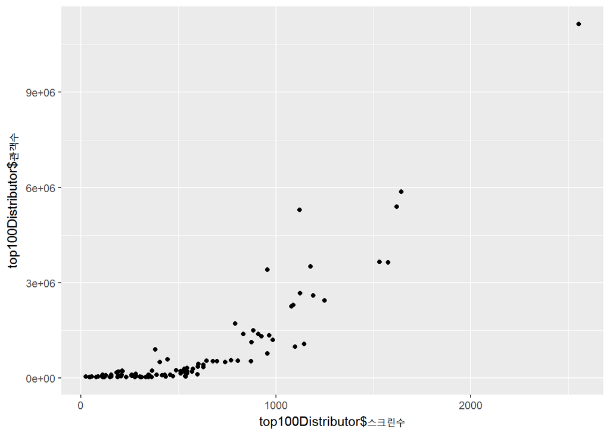

```r
#데이터 전처리
boxoffice2018=read.csv("2018_박스오피스.csv",sep="\t",header=T)
colnames(boxoffice2018)<-c("순위","영화명","개봉일","매출액","매출액점유율","관객수","스크린수","상영횟수","대표국적","국적","배급사")
boxoffice_2018<-boxoffice2018
top100Distributor<-head(boxoffice_2018,100)
#스크린수와 관객수의 상관관계를 확인
#스크린수가 1000개일 때 까지는 영화 관객수의 차이가 크지 않다.
#하지만 스크린 수가 1000개가 넘어가면 관객수가 많이 증가한다. 스크린 수에 따라 관객수가 비례하여 증가한다. 이는 그만큼 영화관에 투자하여 스크린을 많이 확보하여 관객들도 그만큼 더 많이 확보하는 것으로 보인다.
screen_audience<-ggplot(top100Distributor,aes(top100Distributor$스크린수,top100Distributor$관객수))
screen_audience<-screen_audience+geom_point();screen_audience
```

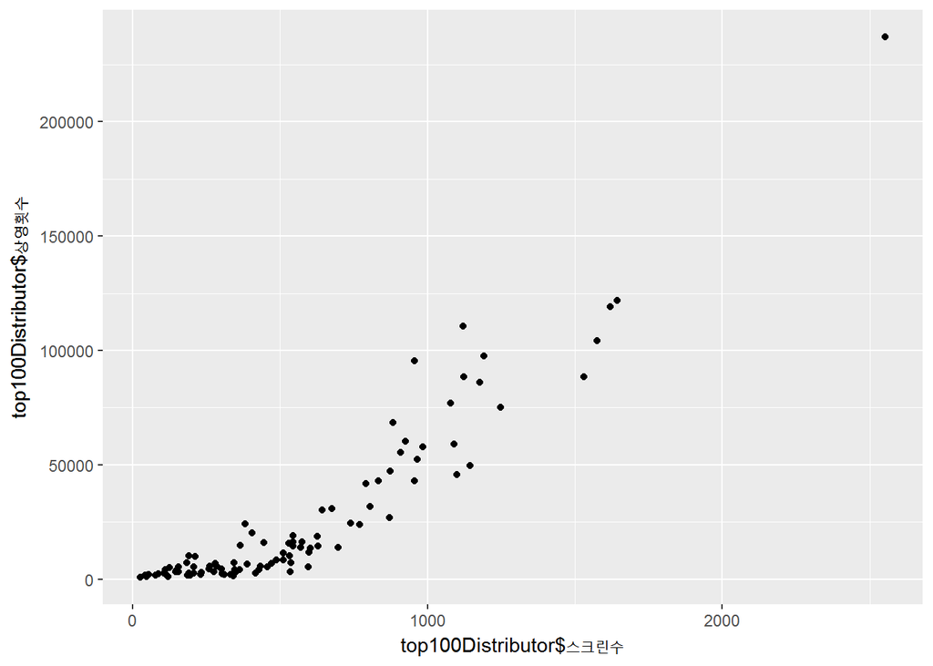

```r
screen_audience<-screen_audience+geom_smooth(method="loess")

#스크린 횟수와 상영횟수 사이에 상관관계
#스크린 수가 많을수록 상영횟수가 많다. 둘의 관계는 정비례 관계로 확인된다.
screen_play<-ggplot(top100Distributor,aes(top100Distributor$스크린수,top100Distributor$상영횟수))
screen_play<-screen_play+geom_point(); screen_play
```

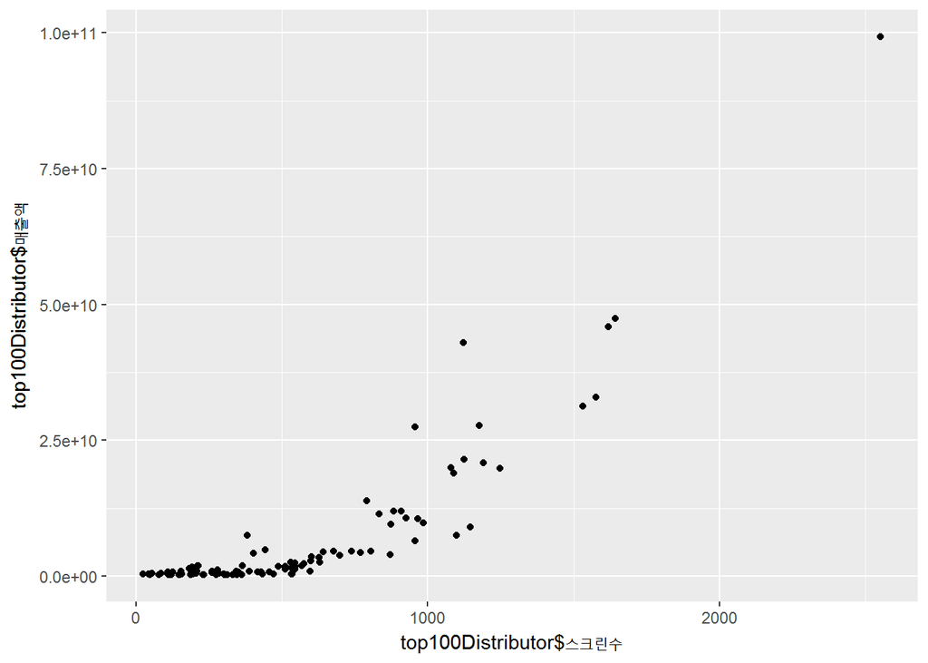

```r
screen_play<-screen_play+geom_smooth(method="loess")

#스크린 수와 매출액 사이의 관계
#스크린 수와 매출액 사이의 편차는 크지만 대체적으로 스크린 수와 매출액 사이에는 정비례 관계가 존재한다. 스크린 수가 많을수록 매출액도 증가한다.
screen_profit<-ggplot(top100Distributor,aes(top100Distributor$스크린수,top100Distributor$매출액))
screen_profit<-screen_profit+geom_point(); screen_profit
```

```r
screen_profit<-screen_profit+geom_smooth(method="loess")
```